# EDA | LFB Incident Records | Project 1 Summary

### Introduction:

The [London Fire Brigade (LFB)](https://www.london-fire.gov.uk/) is the fire and rescue service for London. As of August 2021, it is the busiest and largest of all fire services across the United Kingdom.

The purpose of this exploratory data analysis is to provide insight into the incident records of the LFB from 2009 onwards. Incidents include actual fire, false alarms, lift releases, water leakage within buildings and even suicide attempts. We will explore, for example, time of call, incident type, property type, location and response time. Concurrently, we will make use of the gained knowledge in cleaning, reducing and wrangling our data.

The preprocessed data can then be used for modelling, perhaps in another project segment.

If you have spotted a mistake, or have any comments or enquiries regarding my projects, please don't hesitate to contact me at nghugoryan(at)gmail(dot)com.

### Further details:

If you want the full details of this project, you can check out this [GitHub repository](https://github.com/nghugo/Project_1), which contains the long version [Project 1 GitHub repository ipynb](https://github.com/nghugo/Project_1/blob/main/EDA%20-%20London%20Fire%20Brigade%20-%20Project%201.ipynb) of this markdown. The same link can also be found at the end of this page.

### Licensing:

- Contains Ordnance Survey data © Crown copyright and database right 2012
- Contains Ordnance Survey data © Crown copyright and database right 2015
- Contains National Statistics data © Crown copyright and database right 2012
- Contains National Statistics data © Crown copyright and database right 2015

The London Fire Brigade datasets used in this analysis are found [here](https://data.london.gov.uk/dataset/london-fire-brigade-incident-records). They are public sector information licensed under the [Open Government Licence v2.0](http://www.nationalarchives.gov.uk/doc/open-government-licence/version/2/). They are authored and managed by LFB Information Management at data@london-fire.gov.uk.

The London Borough map used in this analysis is found [here](https://data.london.gov.uk/dataset/london-borough-profiles). It is public sector information licensed under the [Open Government Licence v2.0](http://www.nationalarchives.gov.uk/doc/open-government-licence/version/2/). It is authored by the Greater London Authority and managed by Opinion Research and General Statistics (GLA) at datastore@london.gov.uk.

## 1. Import libraries and load datasets

```python
import numpy as np
import pandas as pd
import geopandas as gpd
import matplotlib.pyplot as plt
import seaborn as sns  # seaborn version 0.10.1 or up required to avoid errors

%matplotlib inline
sns.set(style='whitegrid', rc={'grid.color': '.9', 'axes.edgecolor': '.4'})  # set seaborn style
```

As of August 2021, the incident records from 2009 onwards are split across three `.xlsx` files in chronological order. The ranges are:

```
01/01/2009 - 31/12/2012               (loaded as pandas dataframe df1)
01/01/2013 - 31/12/2016               (loaded as pandas dataframe df2)
01/01/2017 - end of previous month    (loaded as pandas dataframe df3)
```

Recall the three `.xlsx` files can be found [here](https://data.london.gov.uk/dataset/london-fire-brigade-incident-records).

- The first two files have been finalized. We will load them locally.
- The last file will be updated quarterly by the LFB Information Management at this [download link](https://data.london.gov.uk/download/london-fire-brigade-incident-records/b8f76a50-c7a0-4ff4-b3e4-7a42c5d0e8e3/LFB%20Incident%20data%20from%20January%202017.xlsx) to include the newest incident records. To reflect such updates, we will load it via the link.

(If you want to experiment, these files can take a while to load as each of them contain over 400,000 rows. It took me 6 minutes to run the cell below.)

```python
df1 = pd.read_excel('LFB Incident data from January 2009 to December 2012.xlsx')
df2 = pd.read_excel('LFB Incident data from January 2013 to December 2016.xlsx')
url = 'https://data.london.gov.uk/download/london-fire-brigade-incident-records/b8f76a50-c7a0-4ff4-b3e4-7a42c5d0e8e3/LFB%20Incident%20data%20from%20January%202017.xlsx'
df3 = pd.read_excel(url)
```

## 2. Basic exploration after cleaning (truncated for brevity)

After reading and getting our data into a right format (combine datasets, fix or change datatypes, sort in chronological order and remove redundant columns) and conducting a train-test split, we name our end result dataframe `train_F_chrono`, which stands for the training set of fire related incidents of the London Fire Brigade.

Recall you can see the full version of this code at my [Project 1 GitHub repository ipynb](https://github.com/nghugo/Project_1/blob/main/EDA%20-%20London%20Fire%20Brigade%20-%20Project%201.ipynb).

Now we are ready to start our exploratory data analysis. First, let's have a look at five randomly picked observations of our dataframe:

```python
train_F_chrono.sample(n = 5)
```

|  | DateOfCall | HourOfCall | IncidentGroup | StopCodeDescription | PropertyCategory | PropertyType | AddressQualifier | IncBoroughName | FRS | IncidentStationGround | FirstPumpArriving_AttendanceTime | FirstPumpArriving_DeployedFromStation |
| --- | --- | --- | --- | --- | --- | --- | --- | --- | --- | --- | --- | --- |
| 338523 | 2012-12-21 | 11 | False Alarm | AFA | Dwelling | Purpose Built Flats/Maisonettes - Up to 3 stor... | Correct incident location | Westminster | London | Euston | 217.0 | Soho |
| 822098 | 2019-10-16 | 22 | False Alarm | AFA | Dwelling | Purpose Built Flats/Maisonettes - Up to 3 stor... | Within same building | Redbridge | London | Ilford | 383.0 | Woodford |
| 605803 | 2016-10-15 | 19 | False Alarm | False alarm - Good intent | Outdoor Structure | Outdoor storage | Open land/water - nearest gazetteer location | Bromley | London | Orpington | 551.0 | Biggin Hill |
| 854207 | 2020-04-05 | 17 | Fire | Secondary Fire | Outdoor | Loose refuse | On land associated with building | Redbridge | London | Hainault | 196.0 | Hainault |
| 159995 | 2010-09-28 | 11 | False Alarm | AFA | Non Residential | Bank/Building Society | Correct incident location | Bromley | London | Bromley | 250.0 | Bromley |

Information about the structure of our dataframe:

```python
train_F_chrono.info()
```

```
<class 'pandas.core.frame.DataFrame'>
Int64Index: 742270 entries, 33 to 927776
Data columns (total 12 columns):
 #   Column                                 Non-Null Count   Dtype
---  ------                                 --------------   -----
 0   DateOfCall                             742270 non-null  datetime64[ns]
 1   HourOfCall                             742270 non-null  int64
 2   IncidentGroup                          742270 non-null  category
 3   StopCodeDescription                    742270 non-null  category
 4   PropertyCategory                       742270 non-null  category
 5   PropertyType                           742270 non-null  category
 6   AddressQualifier                       742270 non-null  category
 7   IncBoroughName                         742270 non-null  category
 8   FRS                                    742270 non-null  category
 9   IncidentStationGround                  742270 non-null  category
 10  FirstPumpArriving_AttendanceTime       648527 non-null  float64
 11  FirstPumpArriving_DeployedFromStation  648522 non-null  category
dtypes: category(9), datetime64[ns](1), float64(1), int64(1)
memory usage: 45.9 MB
```

## 3. Univariate analysis

The code for the following plots are too long to include on this page. Please check them out on my [Project 1 GitHub repository ipynb](https://github.com/nghugo/Project_1/blob/main/EDA%20-%20London%20Fire%20Brigade%20-%20Project%201.ipynb).

#### 1. Numerical or ordinal categorical features :

##### Histogram

(Cell 33 in [Project 1 GitHub repository ipynb](https://github.com/nghugo/Project_1/blob/main/EDA%20-%20London%20Fire%20Brigade%20-%20Project%201.ipynb))

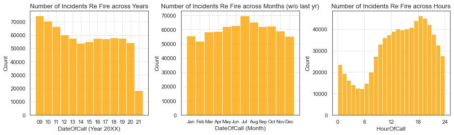

##### Interpretation of the above results:

- There was a noticeable drop in the number of fire related incidents (real fire/ false alarms) from 2009 to 2014, followed by a plateau or very slight increase from 2015 to 2020. For 2021, we must bear in mind that its records are not complete. Hence the number of incidents for the year 2021 is distinctly small. When you view this markdown, these records might have been updated. You should similarly take the number of incidents for the last year with a grain of salt.
- Cases peaked towards summer(May-Sep), with a gradual drop moving away (forwards/backwards) from summer, until reaching a valley in Feb. Since we have removed records in the last year for `Months`, we can rest assured that the partial records in the last year (records only up to a certain month) does not contribute to the plot, and hence will not skew the plot with an increase in numbers for the earlier months. It may be possible to correspond an increase of fire related incidents with weather patterns in the summer (eg higher heat) or activities done in the summer.
- Cases are significantly high around 12:00 to 21:00, with a peak at 18:00. Outside of these hours, the number of cases fall sharply. It may be possible to correspond an increase of fire related incidents with activities done in the afternoon. However, we should also remember that there is inherently more activity in daylight hours as most people work in the day, hence such increase can also be purely natural.

##### Histogram, kernel density plot and boxplot

(Cell 34 in [Project 1 GitHub repository ipynb](https://github.com/nghugo/Project_1/blob/main/EDA%20-%20London%20Fire%20Brigade%20-%20Project%201.ipynb))

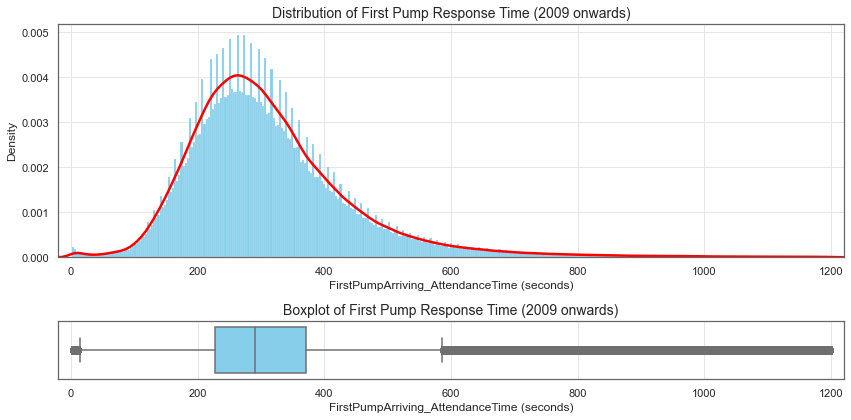

#### 2. Nominal categorical features

##### Histogram

(Cell 36 in [Project 1 GitHub repository ipynb](https://github.com/nghugo/Project_1/blob/main/EDA%20-%20London%20Fire%20Brigade%20-%20Project%201.ipynb))

Now we plot histograms for each nominal categorical variable. From our detailed analysis at [Project 1 GitHub repository ipynb](https://github.com/nghugo/Project_1/blob/main/EDA%20-%20London%20Fire%20Brigade%20-%20Project%201.ipynb), we know some categories have many unique values. Hence, displaying everything results in clutter. We will only display at most the top 6 most frequent values for each category.

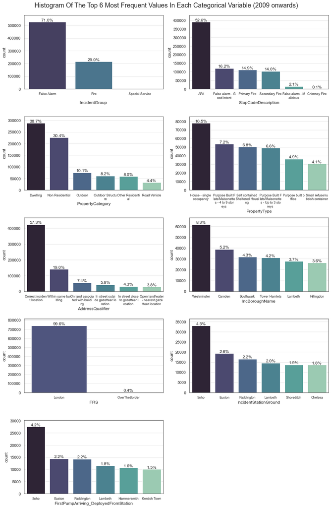

##### Interpretation of the above results:

- `IncidentGroup`:
  - Most fire related incidents are false alarms (around 70%). The remaining are actual fire incidents. Recall we have partitioned `IncidentGroup` and put all special service incidents from `combined_df` in `df_S`. Hence, there are no special service incidents here.
- `StopCodeDescription`:
  - Around half of all incidents are set off by automatic fire alarms. 20% of all incidents are false alarms (good intent or malicious) reported by people, and the remaining 30% are actual fire.
  - Side note: `AFA` in `StopCodeDescription` means automatic fire alarm.
- `PropertyCategory`:
  - Dwelling and non-residential buildings account for the majority of incidents. However we need to account for the fact that most properties are of these two types. Hence, it might not be that these properties are inherently more prone to fire. Otherwise, the remaining incidents come from, for example, outdoors, other residential buildings such as hotels, and vehicles.
- `PropertyType`:
  - There doesn't seem to be anything particularly interesting. However, note that the top 6 values of `PropertyType` only account for around 40% of all values. Hence, incidents are rather evenly spread across different values.
- `AddressQualifier`:
  - Firefighters are correctly informed of over half of all cases. But this also means that many cases do not have a precise reported location.
- `IncBoroughName`:
  - Westminster, being the core of Central London, accounts for over 8% of all fire related incidents of London. Otherwise, incidents are rather evenly spread across other boroughs.
- `FRS`:
  - Almost all fire related incidents in London are dealt with internally by the fire and rescue services in London, ie the London Fire Brigade. Otherwise, the remaining 0.4% of cases are dealt with by services from outside.
- `IncidentStationGround`:
  - Soho, being the main entertainment district of Westminster, accounts for the most incidents among all station grounds, where a station ground is the region a particular fire station monitors. Otherwise, incidents are rather evenly spread across other station grounds.
- `FirstPumpArriving_DeployedFromStation`:
  - Again, the Soho station ground accounts for most deployment. Since the top four values in `IncidentStationGround` correspond exactly with `FirstPumpArriving_DeployedFromStation`, we have strong reason to believe that stations, most of the time, respond to their own monitored regions.

##### Choropleth map

(Cells 37-46 in [Project 1 GitHub repository ipynb](https://github.com/nghugo/Project_1/blob/main/EDA%20-%20London%20Fire%20Brigade%20-%20Project%201.ipynb). Since `bokeh` is `JavaScript` based, which`github.com` blocks, the plot will not render there.)

Plotting `IncBoroughName` on a choropleth map. This map was created using the libraries `geopandas` and `bokeh`. The shape of the map come from [here](https://data.london.gov.uk/dataset/london-borough-profiles) in the London Datastore.

```python
from IPython.display import IFrame
IFrame(src='./F_inc_map.html.', width=900, height=700)
```

[interactive chart not shown]

##### Interpretation of the above results:

- The central part of London tend to have the highest number of cases, with `Westminster` accounting for >60000 cases. All three boroughs with >30000 cases (`Southwark`, `Tower Hamlets` and `Camden`) are in very close proximity to the very centre of London. Of the central part, the only region with under 20000 cases is the `City of London`. However, we can explain this phenomenon in the next point.
- When looking at the map, we should bear in mind that boroughs/regions come in different sizes. It is natural for bigger boroughs to contain more people and/or properties, and hence see more cases. This also explains why the `City of London`, being the tiniest region, although located in the very centre of London where we would expect a lot of cases, in truth has very few cases.
- To account for region sizes, we can conduct another analysis where we divide the number of cases in a region by the region size. Doing so, we look at the concentration of cases in each region, rather than just the absolute number. Such adjustment better informs us which regions are actually more prone to fire or false alarm incidents.

## 4. Bivariate/multivariate analysis

We will conduct bivariate/multivariate analysis as follows:

1. Numerical to numerical features
   - `FirstPumpArriving_AttendanceTime` and `MonthYear` (`MonthYear` extracted from `DateOfCall`)
   - `FirstPumpArriving_AttendanceTime` and `HourOfCall`

     Methods: line plots
1. Numerical to categorical features
   - `FirstPumpArriving_AttendanceTime` and `AddressQualifier`
   - `HourOfCall`, `PropertyCategory` and `IncidentGroup`

     Methods: violin plots, side-by-side bar charts
1. Categorical to categorical features
   - `StopCodeDescription` and `PropertyCategory`
   - `IncidentStationGround` and `FirstPumpArriving_DeployedFromStation`

     Methods: stacked bar charts, regular bar charts

#### 1. Numerical to numerical features

##### 1i. `FirstPumpArriving_AttendanceTime` and `MonthYear`

(Cell 49 in [Project 1 GitHub repository ipynb](https://github.com/nghugo/Project_1/blob/main/EDA%20-%20London%20Fire%20Brigade%20-%20Project%201.ipynb))

We consider:

- a month as the interval size.
- the entire London area for the mean `FirstPumpArriving_AttendanceTime`

Below, we will

1. Use `train_F_chrono`, which has observations sorted in chronological order of `DateOfCall`
2. Filter out observations with missing `FirstPumpArriving_AttendanceTime`
3. Extract month and year from `DateOfCall` and group, keeping the above order unchanged
4. Create a lineplot of `FirstPumpArriving_AttendanceTime` against `MonthYear`

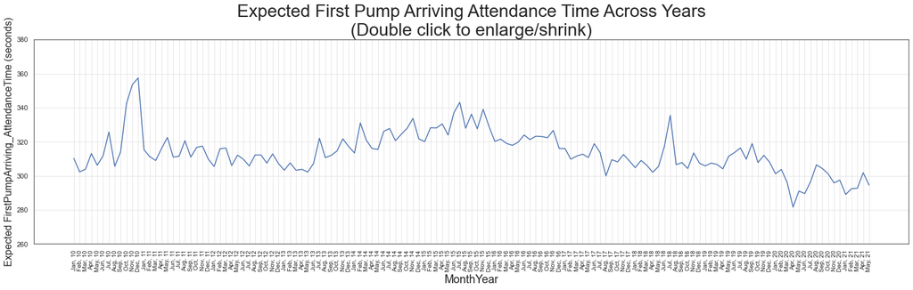

##### Interpretation of the above results:

We know that a lower response time is better.

Also note that the peaks and valleys of the above line graph are exaggerated for easy distinction. If we were to set the lower y-axis limit of the plot to 0, then the plot line is quite close to a flat line.

##### 1ii. `FirstPumpArriving_AttendanceTime` and `HourOfCall`

(Cell 50 in [Project 1 GitHub repository ipynb](https://github.com/nghugo/Project_1/blob/main/EDA%20-%20London%20Fire%20Brigade%20-%20Project%201.ipynb))

We analyze how the mean `FirstPumpArriving_AttendanceTime` (average response time to false alarms or fires) vary over each hour. We also apply smoothening to the plot to account for values in between hours.

We consider:

- an hour as the interval size.
- the entire London area for the mean `FirstPumpArriving_AttendanceTime`

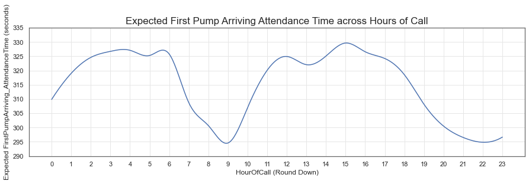

##### Interpretation of the above results:

We know that a lower response time is better.

The expected first pump arriving attendance time (response time) ranges from 295 seconds to 330 seconds. Valleys occur around 9am and 10pm. Otherwise, attendance time gradually increases away from these two hour marks, reaching peaks near 4am and 3pm.

#### 2. Numerical to categorical features

##### 2i. `FirstPumpArriving_AttendanceTime` and `AddressQualifier`

(Cell 51 in [Project 1 GitHub repository ipynb](https://github.com/nghugo/Project_1/blob/main/EDA%20-%20London%20Fire%20Brigade%20-%20Project%201.ipynb))

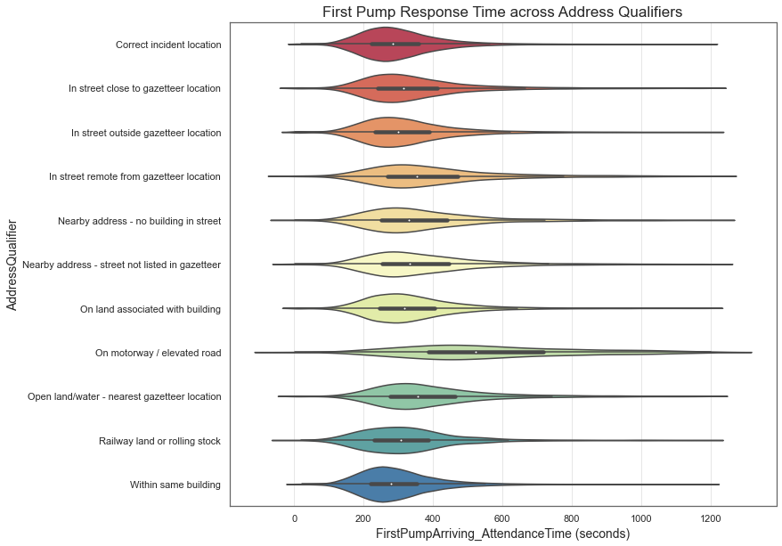

##### Interpretation of the above results:

We know that a lower response time is better.

The `seaborn` violin plot is a combination of a boxplot and a kernel density plot. In our graph, the kernel densities are colored, and the boxplots are the bars inside each violin.

The first pump arriving attendance times (`AddressQualifier`) (response time) across different qualities of reported location, except `On motorway / elevated road`, have medians (white dot inside each violin) within 200 and 400 seconds. They share similar interquartile ranges (thick lines within each violin) and upper and lower adjacent values (thin lines within each violin).

The exception of `On motorway / elevated road` has a median around 500 seconds, a greater interquartile range, a higher upper adjacent value and a smaller lower adjacent value.

As we would expect, when the reported location is less precise, the response time goes up and can be more varied. In this case, precision can be determined by the size of the reported area and the distance from the actual location.

Also, when the reported location is harder to reach, the response time also goes up. For example, motorways, elevated roads or open land/water, compared to usual streets, take more time to reach from fire stations.

##### 2ii. `HourOfCall` and `PropertyCategory`

(Cells 52-53 in [Project 1 GitHub repository ipynb](https://github.com/nghugo/Project_1/blob/main/EDA%20-%20London%20Fire%20Brigade%20-%20Project%201.ipynb).)

Let's review the unique values of `PropertyCategory`:

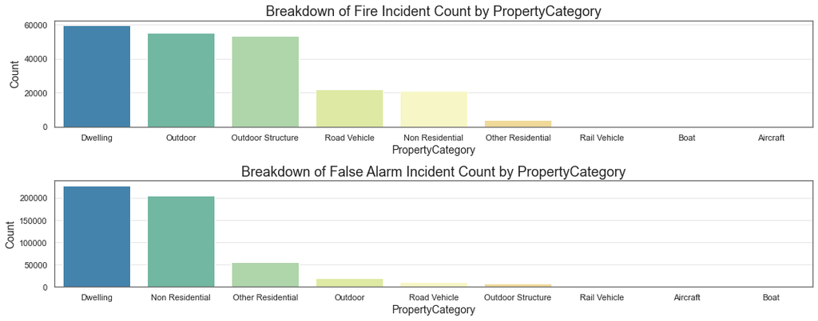

Currently, there are 24 hour levels and 9 unique values of PropertyCategory (excluding missing values). If we plot a side-by-side bar chart, with each group containing `PropertyCategories` and spread across 24 hour levels, we will end up with 24×9=216 bars. There are too many to visualize on a single plot

The strategy will be to

- homogenize 4 hour intervals
- homogenize `Road Vehicle`, `Rail Vehicle`, `Boat` and `Aircraft` as `Vehicles` due to their low counts

This results in 6×6=36 bars only.

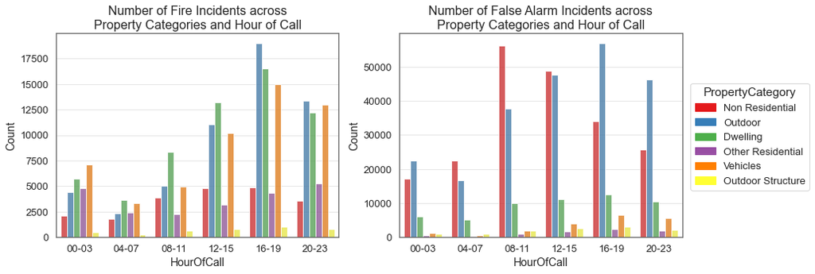

##### Interpretation of the above results:

The number of incidents across different property categories rise and fall follow a similar trend, rising and falling as `HourOfCall` vary. Such trend is similar to what we see in the histogram for `HourOfCall` of the univariate analysis of `train_F_chrono`.

#### 3. Categorical to categorical features

##### 3i. `StopCodeDescription` and `PropertyCategory`

(Cells 55-56 in [Project 1 GitHub repository ipynb](https://github.com/nghugo/Project_1/blob/main/EDA%20-%20London%20Fire%20Brigade%20-%20Project%201.ipynb))

From `train_F_chrono.info()` in the start of our bivariate analysis, there are no missing values in these features. There are 7 unique values in `StopCodeDescription`. For ease of visualization, we use the same homogenization technique for `PropertyCategory` from `2ii` Then, `PropertyCategory` has 6 unique values. If we use bar charts, this gives us 6×7=42 bars.

Let's use horizontally stacked bar charts, and look at the breakdown of `StopCodeDescription` for each `PropertyCategory`. This means we have `StopCodeDescription` on the horizontal axis `PropertyCategory` on the vertical axis.

We will plot two versions of stacked bar plots: counts and percentages (normalize length to 1).

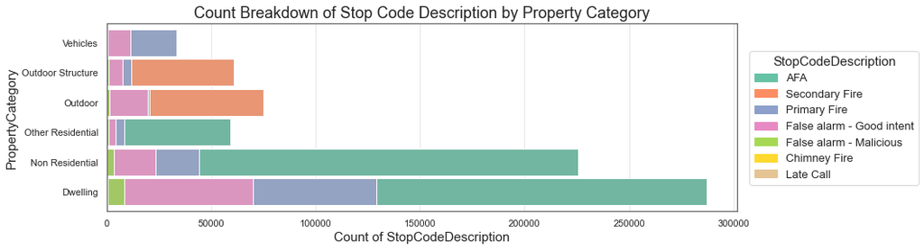

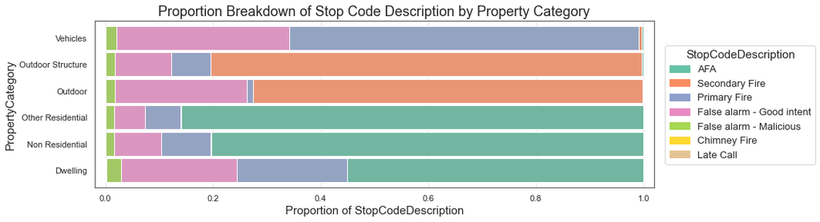

Printing the numbers in the following cell in a human-friendly manner for you to access the above plot. Note this is considered an 'untidy' format of dataframe for computers.

```python
temp_df2.groupby(['PropertyCategory', 'StopCodeDescription']).count().transpose()
```

| PropertyCategory StopCodeDescription | Dwelling AFA | Dwelling Chimney Fire | Dwelling False alarm - Good intent | Dwelling False alarm - Malicious | Dwelling Late Call | Dwelling Primary Fire | Dwelling Secondary Fire | Non Residential AFA | Non Residential Chimney Fire | Non Residential False alarm - Good intent | Non Residential False alarm - Malicious | Non Residential Late Call | Non Residential Primary Fire | Non Residential Secondary Fire | Other Residential AFA | Other Residential Chimney Fire | Other Residential False alarm - Good intent | Other Residential False alarm - Malicious | Other Residential Late Call | Other Residential Primary Fire | Other Residential Secondary Fire | Outdoor AFA | Outdoor False alarm - Good intent | Outdoor False alarm - Malicious | Outdoor Late Call | Outdoor Primary Fire | Outdoor Secondary Fire | Outdoor Structure AFA | Outdoor Structure False alarm - Good intent | … |
| --- | --- | --- | --- | --- | --- | --- | --- | --- | --- | --- | --- | --- | --- | --- | --- | --- | --- | --- | --- | --- | --- | --- | --- | --- | --- | --- | --- | --- | --- | --- |
| Count | 158193 | 387 | 61525 | 8020 | 129 | 58968 | 89 | 181084 | 38 | 19825 | 3500 | 29 | 20727 | 237 | 51083 | 4 | 3472 | 922 | 11 | 3930 | 10 | 70 | 18336 | 1376 | 7 | 810 | 54351 | 189 | 6410 | … |

##### Interpretation of the above results:

Notation: `AFA` in `StopCodeDescription` means automatic fire alarm.

Also, fire stations might consider using this breakdown information in better arming themselves with specific equipment before and when receiving reported incidents. For instance, the desired equipment setup for a primary fire can differ from that for a secondary fire. Since vehicle fires are mostly primary, and outdoor fires are mostly secondary, the desired equipment setup for an outdoor fire can differ from that for a vehicle fire. It may be beneficial if fire stations prepare different sets of equipment according to this analysis on incident types, before any incidents actually occur. When mobilization is needed, they can load the needed sets of equipment for a best response to incidents.

##### 3ii. `IncidentStationGround` and `FirstPumpArriving_DeployedFromStation`

(Cells 58-62 in [Project 1 GitHub repository ipynb](https://github.com/nghugo/Project_1/blob/main/EDA%20-%20London%20Fire%20Brigade%20-%20Project%201.ipynb))

For each incident station ground, let's look at the percentage of cases that the commissioned fire station deals with.

```python
%%capture output

# Goal: First, calculate percentage of correctness. Then 2 bar charts ordered by percentage with station as x axis,
# Show top 5 and bottom 5 stations

# Create a temporary dataframe to facilitate plotting
temp_df3 = train_F_chrono[['IncidentStationGround', 'FirstPumpArriving_DeployedFromStation']]

# Remove observations with missing FirstPumpArriving_DeployedFromStation
temp_df3.dropna(subset=['FirstPumpArriving_DeployedFromStation'], inplace=True)

# Filter out observations with OverTheBorder as IncidentStationGround, as we are interested in the London Fire Brigade only
temp_df3 = temp_df3[~(temp_df3['IncidentStationGround']=='OverTheBorder')]

# Make temp_df3 columns strings for comparision. Also use another variable temp_df4 to avoid errors
temp_df4 = temp_df3.apply(lambda col: col.astype('object'), axis=1).copy()
del temp_df3
```

```python
temp_df4['% Station Match'] = (temp_df4['IncidentStationGround'] == temp_df4['FirstPumpArriving_DeployedFromStation'])
sortedStationMatchDf = temp_df4.groupby('IncidentStationGround').mean().sort_values('% Station Match', ascending=False).reset_index()
sortedStationMatchDf['% Station Match'] = sortedStationMatchDf['% Station Match']*100
```

```python
sortedStationMatchDf.head(5)
```

|  | IncidentStationGround | % Station Match |
| --- | --- | --- |
| 0 | Addington | 90.817264 |
| 1 | Enfield | 89.468276 |
| 2 | Brixton | 88.873203 |
| 3 | Sutton | 88.846520 |
| 4 | Hillingdon | 88.184215 |

```python
sortedStationMatchDf.tail(5)
```

|  | IncidentStationGround | % Station Match |
| --- | --- | --- |
| 97 | Mill Hill | 62.986716 |
| 98 | Dowgate | 61.858654 |
| 99 | Shadwell | 59.958506 |
| 100 | Deptford | 58.609193 |
| 101 | Dockhead | 57.546961 |

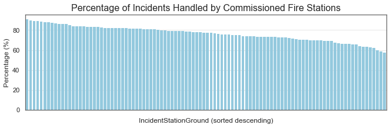

```python
fig, ax = plt.subplots(figsize=(11,3))
sns.barplot(x='IncidentStationGround',  y='% Station Match', data=sortedStationMatchDf, orient='v',
            color = 'skyblue', ax=ax)
plt.setp(ax.patches, linewidth=0)

ax.set_xticklabels([])
ax.set_xlabel('IncidentStationGround (sorted descending)', fontsize = 12)
ax.set_ylabel('Percentage (%)', fontsize = 12)
ax.set_title('Percentage of Incidents Handled by Commissioned Fire Stations', fontsize = 16)

plt.show()
```

##### Interpretation of the above results:

For instance, the `Addington` fire station handles 90.82% of cases within its ground, but the `Dockhead` fire station only handles 57.55% of cases within its ground.

Further investigation by the fire department should be conducted to see if there is an over-reliance of certain fire stations on other fire stations, or whether this reliance is actually optimal.

## Thank you!

Thank you for checking out my project.

If you want the full details of this project, you can check out this [GitHub repository](https://github.com/nghugo/Project_1), which contains the long version [Project 1 GitHub repository ipynb](https://github.com/nghugo/Project_1/blob/main/EDA%20-%20London%20Fire%20Brigade%20-%20Project%201.ipynb) of this markdown.